# Public Health, and Financial, Impact of Natural Disasters in the US

Dr. Vivek Narayan

November 28, 2017

### Synopsis

This report has been created for the purposes of completing an end-of-module project for the Reproducible Research Course offered by the Johns Hopkins Bloomberg School Of Public Health on Coursera. For the purposes of the assignment, storm data from the U.S. National Oceanic and Atmospheric Administration (NOAA) [Website](https://www.ncdc.noaa.gov/stormevents/) was analysed to ascertain the public health and financial impact of natural disasters in the US. From NOAA’s website, “the database contains storm data from January 1950 [to date] as entered by NOAA’s National Weather Service (NWS)”. The report was required to be created for the purposes of de-briefing government officials responsible for preparing for severe weather events and the report format(html) was required to be uploaded on [Rpubs](https://rpubs.com/).

### Loading and Processing Data

For the purposes of the assignment data was downloaded from the assignment provided URL [Link](https://d396qusza40orc.cloudfront.net/repdata%2Fdata%2FStormData.csv.bz2).

```r
library(tidyverse, warn.conflicts = FALSE)
```

```r
DlURL <- "https://d396qusza40orc.cloudfront.net/repdata%2Fdata%2FStormData.csv.bz2"
if(!file.exists("Noaa.bz2")){
  download.file(DlURL, destfile = "./Noaa.bz2")
  }
if(!exists("rawData")){
  rawData <- as.tibble(read.csv(bzfile("./Noaa.bz2")))
  }
```

After loading the data into the local evironment, the function str() was used to identify the column names required for analysis in conjunction with the database documentation from the NOAA website (see supplemental material).

The following subsets of data were created for the purposes of analysis:

- Public Health Impact
- Financial Impact

##### Public Health Impact containing Event-type, Fatalities and Injuries

While fatalities and injuries both need prevention, injuries, require resources to manage and treat. Summing up the two obscures the respective impacts, hence, it was decided to present injuries and fatalities separately.

```r
##Public Health Subset
PHSubsetData <- rawData %>% select(EVTYPE, FATALITIES, INJURIES) %>%
  group_by(EVTYPE) %>% summarise_all(sum)
TopInjuries <- PHSubsetData %>%
  arrange(desc(INJURIES)) %>%
  top_n(10, INJURIES) %>%
  mutate(INJURIES = INJURIES/1000) ##In 1000s for better graphical representation
TopFatalities <- PHSubsetData %>%
  arrange(desc(FATALITIES)) %>%
  top_n(10, FATALITIES) %>%
  mutate(INJURIES = INJURIES/1000) ##In 1000s for better graphical representation
TopPHIssues <- union(TopInjuries, TopFatalities) %>% arrange(desc(FATALITIES))
```

##### Financial Impact containing Eventype and respective columns for property and crop damage.

```r
FinSubsetData <- rawData %>%
  select(EVTYPE, PROPDMG, PROPDMGEXP, CROPDMG, CROPDMGEXP)
unique(FinSubsetData$PROPDMGEXP)
```

```
##  [1] K M   B m + 0 5 6 ? 4 2 3 h 7 H - 1 8
## Levels:  - ? + 0 1 2 3 4 5 6 7 8 B h H K m M
```

```r
unique(FinSubsetData$CROPDMGEXP)
```

```
## [1]   M K m B ? 0 k 2
## Levels:  ? 0 2 B k K m M
```

```r
FinSubsetData <- FinSubsetData %>%
  filter(!(PROPDMGEXP %in% (c("-", "+", "?", "", "0", "5", "3")))) %>%
  filter(!(CROPDMGEXP %in% (c("-", "+", "?", "", "0"))))
##Function to change the damage suffix to numerical amounts
SufFun <- function(char){
  char <- as.character(char);
  char <- gsub("h|H", 100, char);
  char <- gsub("m|M", 1000000, char);
  char <- gsub("b|B", 1000000000, char);
  char <- gsub("k|K", 1000, char);
  char <- as.numeric(char)
}
FinSubsetData$CROPDMGEXP <- SufFun(FinSubsetData$CROPDMGEXP)
FinSubsetData$PROPDMGEXP <- SufFun(FinSubsetData$PROPDMGEXP)
##Total Financial Impact in Billions
SumFinImpact <- FinSubsetData %>%
  mutate(Cost = (CROPDMG*CROPDMGEXP) + (PROPDMG*PROPDMGEXP)) %>%
  group_by(EVTYPE) %>%
  summarise_all(sum) %>%
  mutate(Cost = Cost/10^9) %>%
  arrange(desc(Cost)) %>%
  top_n(15, Cost)
SumFinImpact$Cost <- round(SumFinImpact$Cost, digits = 2)
##Property Damage in Billions
PropDamage <- FinSubsetData %>%
  select(EVTYPE, PROPDMG, PROPDMGEXP) %>%
  mutate(Cost = PROPDMG*PROPDMGEXP) %>%
  group_by(EVTYPE) %>%
  summarise_all(sum) %>%
  mutate(Cost = Cost/10^9) %>%
  arrange(desc(Cost)) %>%
  top_n(10, Cost)
PropDamage$Cost <- round(PropDamage$Cost, digits = 2)
##CropDamage
CropDamage <- FinSubsetData %>%
  select(EVTYPE, CROPDMG, CROPDMGEXP) %>%
  mutate(Cost = CROPDMG*CROPDMGEXP) %>%
  group_by(EVTYPE) %>%
  summarise_all(sum) %>%
  mutate(Cost = Cost/10^9) %>%
  arrange(desc(Cost)) %>%
  top_n(10, Cost)
CropDamage$Cost <- round(CropDamage$Cost, digits = 2)
```

## Results

### Public Heath Impact Due to Injuries and Fatalities

The following bar-charts were created to visualize the events that cause the most (top ten) impact on public health from the perspective of fatalities and injuries.

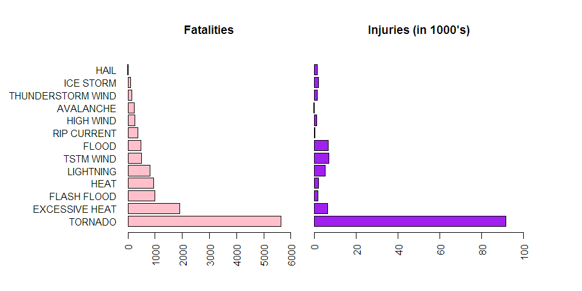

```r
par(mar = c(5,11,5,0))
par(mfrow = c(1,2))
barplot(TopPHIssues$FATALITIES, names.arg = TopPHIssues$EVTYPE, las=2, horiz = T, xlim = c(0,6000), main = "Fatalities", col = "pink")
par(mar = c(5,2,5,5))
barplot(TopPHIssues$INJURIES, las=2, horiz = T, main = "Injuries (in 1000's)", xlim = c(0,100), col = "purple")
```

As can be seen from the chart, Tornadoes, Excessive Heat, and, Flooding are a great threat to public health.

### Financial Impact Due to Crop and Property Damage

The following bar-charts were created to visualize the events that result in the most (top-ten) financial loss due to severe weather.

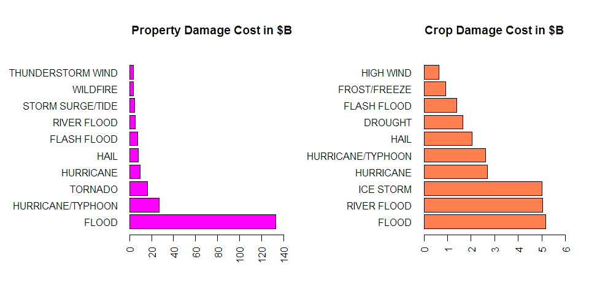

```r
par(mfrow = c(1,2))
par(mar = c(5,11,5,0))
barplot(PropDamage$Cost, names.arg = PropDamage$EVTYPE, las=2, horiz = T, xlim = c(0,150), main = "Property Damage Cost in $B", col = "Magenta")
par(mar = c(5,11,5,2))
barplot(CropDamage$Cost, names.arg = CropDamage$EVTYPE, las=2, horiz = T, main = "Crop Damage Cost in $B", xlim = c(0,6), col = "Coral")
```

As can be seen from the chart, the top causes for crop damage are adverse weather events, such as, Frost, Drought, Hurricanes, and, Floods.

Flooding constitutes the main cause for property damage, followed by, Hurricanes and Tornadoes.

Additionally, the following bar-chart was created to visualize the overall financial impact from severe weather.

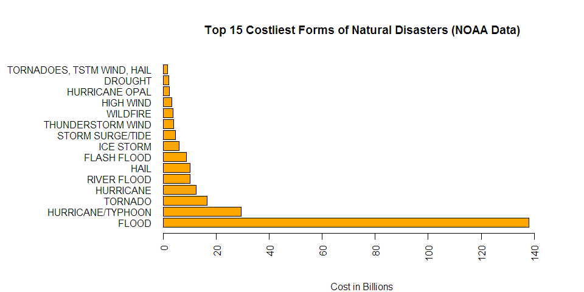

```r
par(mfrow = c(1,1))
par(mar = c(5,14,5,2))
barplot(SumFinImpact$Cost, names.arg = SumFinImpact$EVTYPE, las=2, horiz = T, main = "Top 15 Costliest Forms of Natural Disasters (NOAA Data)", xlim = c(0,150), col = "Orange", sub = "Cost in Billions")
```

As can be seen from the chart, Flooding is a major cause for both crop and property damage.

## Suplemental Material

All files (minus the original data) and code have been uploaded onto Github [Link](https://github.com/maximegalon5/RR-Project-2-NOAA-Data)

Documentation for the Storm-data database can be sourced directly from NOAA’s website [Link](http://www.nws.noaa.gov/directives/sym/pd01016005curr.pdf)

For more information on the Reproducible Research course offered by the Johns Hopkins Bloomberg School of Public Health on Coursera visit the course homepage at [Link](https://www.coursera.org/learn/reproducible-research/home/welcome)